# Peer Assessment 1

## Inputing missing values

Here is the total number of missing values:

```r
sum(is.na(data))
```

```
## [1] 2304
```

Here the code which fills in the missing values using the average number of steps per interval:

```r
data[is.na(data)]<- avg
```

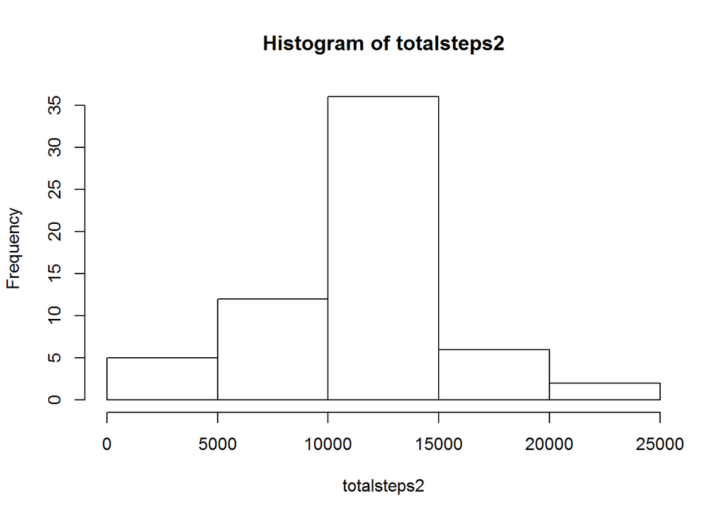

```r
totalsteps2<-tapply(data$steps, data$date, sum)

hist(totalsteps2)
```

```r
mean(data$steps)
```

```
## [1] 37.3826
```

```r
median(data$steps)
```

```
## [1] 0
```

The results from the complete data set do not appear to be very different from those generated from the incomplete data set

## Differences in Activity Patterns between Weekdays and Weekends

Here is how to create a new factor variable which will differentiate between weekends and weekdays:

```r
data$date <- as.Date(data$date)
wedays <- c("Monday", "Tuesday", "Wednesday", "Thursday", "Friday")
enddays <- c("Saturday", "Sunday")
data$day <- weekdays(data$date)
data$day[data$day %in% wedays] <- "weekday"
data$day[data$day %in% enddays] <- "weekend"
data$day <- as.factor(data$day)
```

Here is a panel plot comparing activity patterns between the two time frames:

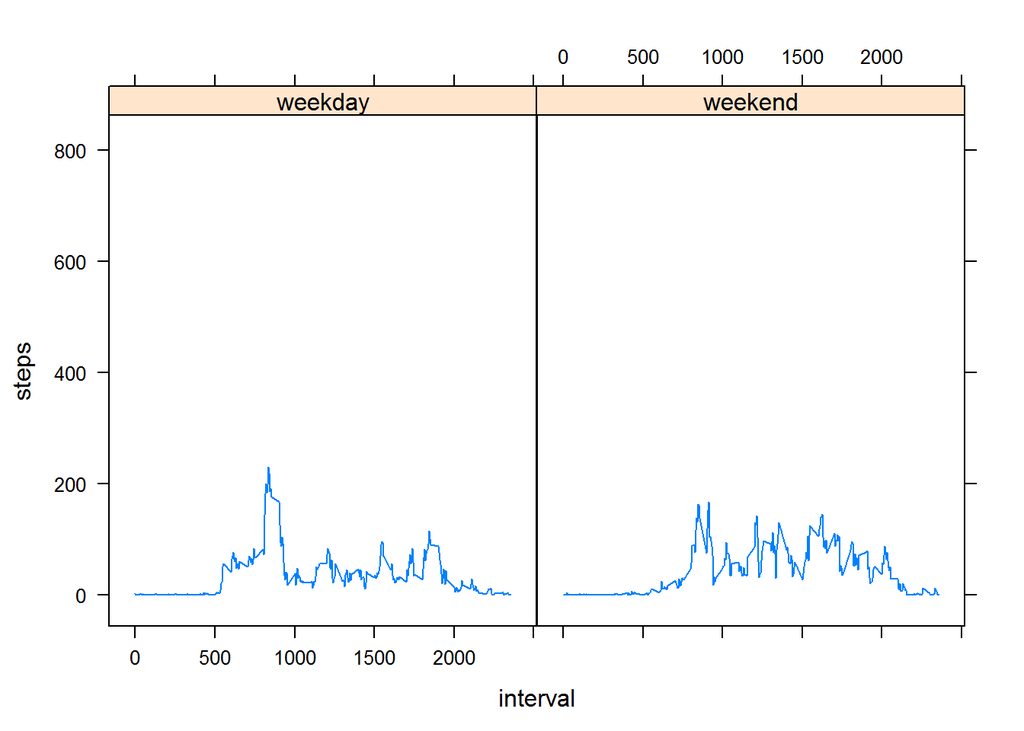

```r
library(lattice)

xyplot(steps ~ interval|day, data = data, type = "a")
```